# Methodological advancements on the use of administrative data in Official Statistics - User Manual 2

Dec 2022

# Overview of Quality measures indicators

To measure the quality of administrative data, we need a benchmark data. It is ideal if a small sample of **Census** data is available. In such scenario, we have information on the *true* population distribution. However, we may not have access to Census data. In this case, one can use **weighted sample survey data** as a source of benchmark, which is used as reference to administrative data.

## What are distance metrics?

Distance metrics is one of the methods that can assess similarity of the administrative data in reference to weighted survey counts (or census data).

To calculate distance metrics, we first obtain one-way, and two-way frequency tables of categorical variables, and calculates proportions of each sub-category by each data source. Next, we combines master (benchmark) and admin freq tables. Then, we create domains for quality indicators, and finally compute distance metrics as part of quality indicators. We offer three different types of distance metrics. To allow comparison across the metrics, we standardise the calculations.

Users can also produce a summary table of three types of distance metrics, and visualise the results.

## What are R-indicators?

# RUNNING 2_Prep_Wtsample_Freq_Table.R

This code file consists of two parts: generating a weighted sample data, and preparing an auxiliary file for R-indicators.

## PREP PART 1: Generate a weighted sample data

- Open the `2_Prep_Wtsample_Freq_Table.R` file.
- Step 1: Load a small percentage of Census data. It is called **pop_u_short_before_sim_5vars** in the provided example code.

```r
        #H---------------------------------------
        ##> 1. Load Census data
        #H--------------------------------------

        load("pop_u_short_before_sim_5vars.RData")
        df  <- pop_u_short_before_sim_5vars
        dim(df)   # obs = 1163659
        names(df)
```

> In our example Census data, we have 1,163,659 observations with five categorical variables including `geography`, `sex`, `age groups`, `ethnic groups`, and `economic activity status`. One can declare which variable to tabulate. Here, we declare all five variables using `var` object[^1].

```r
  var <- c("geog1", "sex", "agecode1",
            "eth_code5", "econg")
```

The description of categories, and distribution is shown below.

| Variable | Category | Description | N | (%) |
| --- | --- | --- | --- | --- |
| Total |  |  | 1163659 |  |
| geog1 | 1 | LA codes | 116128 | (10.0) |
|  | 2 | LA codes | 150139 | (12.9) |
|  | 3 | LA codes | 137520 | (11.8) |
|  | 4 | LA codes | 170624 | (14.7) |
|  | 5 | LA codes | 90873 | (7.8) |
|  | 6 | LA codes | 498375 | (42.8) |
| sex | 1 | male | 564905 | (48.5) |
|  | 2 | female | 598754 | (51.5) |
| agecode1 | 1 | 16-20 | 82426 | (7.1) |
|  | 2 | 21-25 | 94643 | (8.1) |
|  | 3 | 26-30 | 110296 | (9.5) |
|  | 4 | 31-35 | 120398 | (10.3) |
|  | 5 | 36-40 | 119393 | (10.3) |
|  | 6 | 14-45 | 101711 | (8.7) |
|  | 7 | 46-50 | 94209 | (8.1) |
|  | 8 | 51-55 | 100159 | (8.6) |
|  | 9 | 56-60 | 77799 | (6.7) |
|  | 10 | 61-65 | 65833 | (5.7) |
|  | 11 | 66-70 | 57305 | (4.9) |
|  | 12 | 71-75 | 51263 | (4.4) |
|  | 13 | 76-80 | 43678 | (3.8) |
|  | 14 | 81+ | 44546 | (3.8) |
| eth_code5 | 1 | White | 1081812 | (93.0) |
|  | 2 | Mixed/Multiple ethnic groups | 10487 | (0.9) |
|  | 3 | Asian/Asian British | 46446 | (4.0) |
|  | 3 | Black/African/Caribbean/Black British | 16268 | (1.4) |
|  | 4 | Other ethnic group | 8646 | (0.7) |
| econg | 1 | In employment(FT, PT) | 689140 | (59.2) |
|  | 2 | Unemployed | 27744 | (2.4) |
|  | 3 | Out of workforce | 446775 | (38.4) |

> Using this prior information on the population distribution (based on Census), we can mimic the distribution in a random sample. See the next step.
- Step 2: Then, we draw a random sample 1:50.
- Step 3: From the randomly selected sample (`1163659/50 = 23273`), we then obtain frequency table of categorical variables (count of categories). Users can run the pre-defined function, `fn_maxvar5_freq_table()` to perform the task. The function[^2] automatically obtains counts and structure the output in long form, organised by each variable, and by its discrete category.

```r
        fn_maxvar5_freq_table()
```

> This procedure is to *assess distribution* of categories in a random sample (N = 23273). Based on the counts of the randomly selected sample, we multiply the counts by 50. One may wonder why we multiply. As we *reduced* the census sample by drawing a random sample by the 1:50 ratio, we need to *convert* the shrank sample back to the original size (with the priori distribution). That’s why we multiply by 50 (Weighted Sample N = 23273 * 50 = 1163650). This completes the process of generating weighted sample survey data.
- Step 4: Carry out checks to see if the calculated frequency tables are accurate.

```r
        freq_table[1:8, 1:9]
```

```
##   seq twdigits raw_n      n          p oneway v   by1 by2
## 1   1      101  2265 113250 0.09732308      1 1 geog1  01
## 2   2      102  2968 148400 0.12752976      1 1 geog1  02
## 3   3      103  2749 137450 0.11811971      1 1 geog1  03
## 4   4      104  3502 175100 0.15047480      1 1 geog1  04
## 5   5      105  1846  92300 0.07931938      1 1 geog1  05
## 6   6      106  9943 497150 0.42723327      1 1 geog1  06
## 7   7      201 11307 565350 0.48584196      1 2   sex  01
## 8   8      202 11966 598300 0.51415804      1 2   sex  02
```

```r
        # Check whether the total adds up to 1
        sum(freq_table[1:6, "n"])
```

```
## [1] 1163650
```

```r
        sum(freq_table[1:6, "p"])
```

```
## [1] 1
```

- Step 5: Rename and save.
- Step 6: Export the output frequency table in Excel with the file name, **Weightedsample_freq_table.xlsx**.
- Step 7: Save the R objects as RData. Done.

## PREP PART 2: Auxiliary file for R-indicators

For R-indicator calculations, we need to compute `meanpop` by variables which are `geography`, `sex`, `age groups`, `ethnic groups`, and `economic activity status`.

```r
        # Compute meanpop
        auxiliary  <- freq_table %>%
                  filter(oneway == 1) %>%
                  group_by(by1) %>%
                  mutate(meanpop = n / popsize) %>%
                  ungroup()  %>%
                  dplyr::select(seq, count = n, by1,
                   v, by2, meanpop, raw_n)
```

To do so, we first remove two-way and keep the one-way frequency table only. Then, by variable-level, which is indicated by `by1`, we compute `meanpop`. As seen before, the count of each category is stored in `n`. The `meanpop` is obtained by dividing `n` by `popsize`. For example, the value of **meanpop** for first category of `geog1` is calculated as `113250/1163650 = 0.0973`, and the second category of `geog1` is `148400/1163650 = 0.1275` and so on.

Finally, we add the `popsize` in the first row, to complete the Auxiliary file.

Let’s look at the Auxiliary file:

```r
        print(wtsample_auxiliary_econg)
```

```
##    seq   count       by1 v by2     meanpop raw_n     type
## 1    1 1163650     total 0  00 1.000000000     0 wtsample
## 2    2  113250     geog1 1  01 0.097323078  2265 wtsample
## 3    3  148400     geog1 1  02 0.127529756  2968 wtsample
## 4    4  137450     geog1 1  03 0.118119710  2749 wtsample
## 5    5  175100     geog1 1  04 0.150474799  3502 wtsample
## 6    6   92300     geog1 1  05 0.079319383  1846 wtsample
## 7    7  497150     geog1 1  06 0.427233275  9943 wtsample
## 8    8  565350       sex 2  01 0.485841963 11307 wtsample
## 9    9  598300       sex 2  02 0.514158037 11966 wtsample
## 10  10   84600  agecode1 3  01 0.072702273  1692 wtsample
## 11  11   93300  agecode1 3  02 0.080178748  1866 wtsample
## 12  12  111200  agecode1 3  03 0.095561380  2224 wtsample
## 13  13  124250  agecode1 3  04 0.106776092  2485 wtsample
## 14  14  118200  agecode1 3  05 0.101576935  2364 wtsample
```

[output cut: 17 more lines]

# RUNNING 3_A_Distance_Metrics.R

This file allows us to compute distance metrics.

The preliminary step is to ensure we have benchmark data. Simply *source* the previous file as below to update it.

```r
        source("2_Prep_Wtsample_Freq_Table.R")
```

- Step 1: read admin data

```r
        df  <- read_csv("public_release_admin.csv")
        tail(df)
```

```
## # A tibble: 6 x 6
##   person_id geog1a   sex agecode1 eth_code5 econg
##       <dbl>  <dbl> <dbl>    <dbl>     <dbl> <dbl>
## 1   1033659      1     1        6         1     1
## 2   1033660      6     1        6         1     1
## 3   1033661      6     2        5         1     1
## 4   1033662      5     1       12         1     3
## 5   1033663      1     2        9         1     1
## 6   1033664      6     2        9         1     1
```

The last six observations of the example admin data is shown above. As the person id goes up to 1033664, we can see there are `1033664` observations in admin data. We also notice that `geog1a` is used instead of *geog1*. As such, we declare all five variables for tabulations.

```r
  var <- c("geog1a", "sex", "agecode1",
            "eth_code5", "econg")
```

- Step 2: Obtain admin freq tables.

As mentioned in the previous section, we obtain frequency table of categorical variables (count of categories). Users can run the pre-defined function, `fn_maxvar5_freq_table()` to perform the task. The function[^3] automatically obtains counts and structure the output in long form, organised by each variable, and by its discrete category.

Once the frequency tables are obtained, we rename the object as `Admin_f_table_one`. Let’s inspect `Admin_f_table_one`.

```r
        head(Admin_f_table_one)
```

```
##   seq twdigits admin_n admin_perc oneway v    by1 by2    by3 by4 by5
## 1   1      101  137993  0.1334989      1 1 geog1a  01 oneway   0   0
## 2   2      102  124051  0.1200110      1 1 geog1a  02 oneway   0   0
## 3   3      103  131176  0.1269039      1 1 geog1a  03 oneway   0   0
## 4   4      104  139867  0.1353119      1 1 geog1a  04 oneway   0   0
## 5   5      105  142304  0.1376695      1 1 geog1a  05 oneway   0   0
## 6   6      106  358273  0.3466049      1 1 geog1a  06 oneway   0   0
```

```r
       tail(Admin_f_table_one)
```

```
##     seq twdigits admin_n   admin_perc oneway v       by1 by2   by3 by4 by5
## 340 340   404501    8557 0.0082783187      2 4 eth_code5  04 econg   5  01
## 341 341   404502     791 0.0007652390      2 4 eth_code5  04 econg   5  02
## 342 342   404503    5007 0.0048439338      2 4 eth_code5  04 econg   5  03
## 343 343   405501    3867 0.0037410609      2 4 eth_code5  05 econg   5  01
## 344 344   405502     255 0.0002466953      2 4 eth_code5  05 econg   5  02
## 345 345   405503    3420 0.0033086187      2 4 eth_code5  05 econg   5  03
```

- Step 3: Merge admin + Weighted sample freq tables

```r
       fn_merge_one_admin_wtsample_f_table_temp()
```

The code above executes merging two data sources.

- Step 4: Create domains of quality indicators

```r
        fn_create_domain_temp()
```

To check the domains, we can use *Janitor* package’s `tabyl` function[^4]. The function creates 15 domains, including five single variables’ domain, and ten bivariate domains.

```r
        display_domain %>% tabyl(fct_domain)
```

```
##          fct_domain  n     percent
##               geog1  6 0.017391304
##                 sex  2 0.005797101
##            agecode1 14 0.040579710
##           eth_code5  5 0.014492754
##               econg  3 0.008695652
##           geog1:sex 12 0.034782609
##      geog1:agecode1 84 0.243478261
##     geog1:eth_code5 30 0.086956522
##         geog1:econg 18 0.052173913
##        sex:agecode1 28 0.081159420
##       sex:eth_code5 10 0.028985507
##           sex:econg  6 0.017391304
##  agecode1:eth_code5 70 0.202898551
##      agecode1:econg 42 0.121739130
##     eth_code5:econg 15 0.043478261
```

- Step 5: Compute distance metrics

Run the functions to compute three types of distance metrics.

```r
        fn_unstd_distance_metrics_full()
        fn_unstd_distance_metrics_tidy()
```

The functions draw on the formulae as given below.

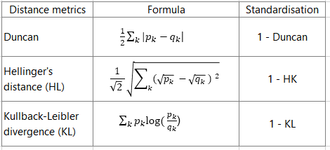

- Step 6: Standardise distance metrics
- Step 7: Reshape, then tidy

From wide form, the outputs have been reshaped to long form. Then, we keep standardised solutions. The results are as follows:

```r
      df <- distance_metrics_long
      # std_test(1-Duncan, 1-HD, 1-KL) only
      df <- df %>% filter(std_test_use == 1)

      df[1:9, c(1:2, 4:5, 9)]
```

```
## # A tibble: 9 x 5
##   domain_id domain   indicator  index std_test_use
##       <int> <chr>    <chr>      <dbl>        <dbl>
## 1         1 geog1    Std_Duncan 0.897            1
## 2         1 geog1    Std_t_HD   0.911            1
## 3         1 geog1    Std_t_KL   0.957            1
## 4         2 sex      Std_Duncan 0.987            1
## 5         2 sex      Std_t_HD   0.991            1
## 6         2 sex      Std_t_KL   1.00             1
## 7         3 agecode1 Std_Duncan 0.946            1
## 8         3 agecode1 Std_t_HD   0.953            1
## 9         3 agecode1 Std_t_KL   0.987            1
```

- Step 8: Plot the distance metrics

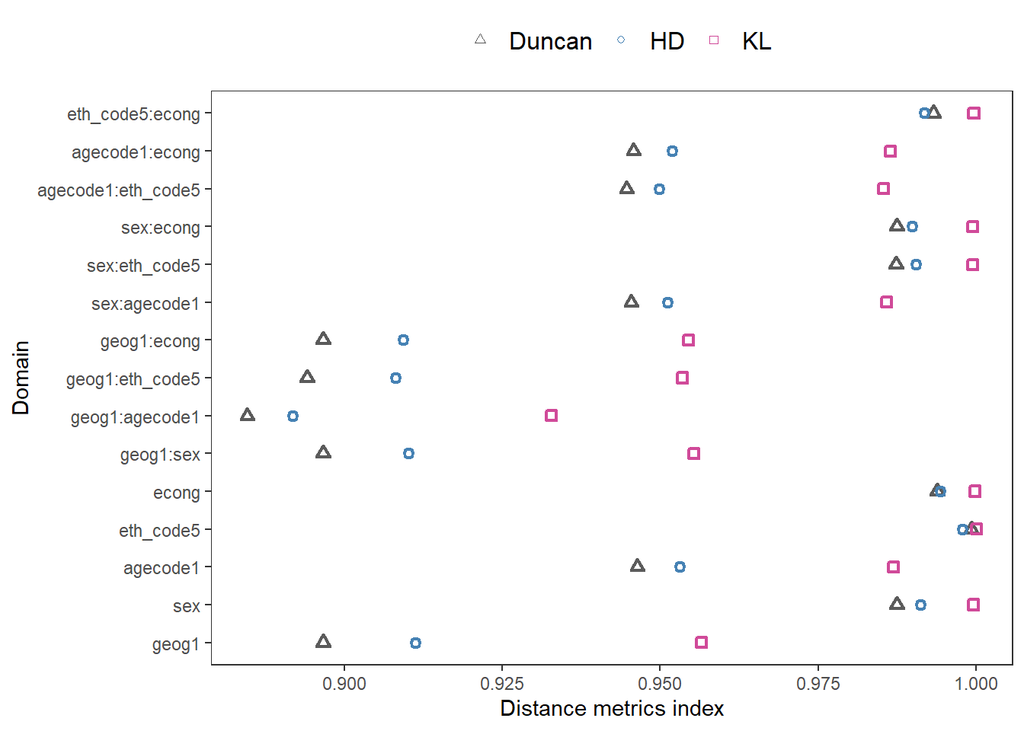

```r
         plot(p)
```

# RUNNING 3_B_R-indicator.R

The file computes the overall R-indicator. Users can also proceed with computing **partial** R-indicators by category level, and variable level. The procedure can be computationally extensive. This is noted in the relevant section, so that users can allow some time to execute the code.

- Step 1: Benchmark mean population ready

Load auxiliary file and remove the last category From each categorical variable (`group_by(by1)`), we identify the last category (`max(by2)`). We then remove the last category(`dplyr::select(-c(lastcat_, lastcat))`). Here, we explicitly instruct R to use `dplyr` package to access `select` function[^5].

We only need `meanpop`. It is shown in a single column (column vector). Let’s check.

```r
        # Print meanpop
        print(col_auxiliary[1:nrow(col_auxiliary), "meanpop"],
            n = nrow(col_auxiliary))
```

```
## # A tibble: 26 x 1
##    meanpop
##      <dbl>
##  1 1
##  2 0.0973
##  3 0.128
##  4 0.118
##  5 0.150
##  6 0.0793
##  7 0.486
##  8 0.0727
##  9 0.0802
## 10 0.0956
## 11 0.107
## 12 0.102
## 13 0.0859
## 14 0.0823
## 15 0.0822
## 16 0.0674
## 17 0.0581
## 18 0.0498
## 19 0.0435
## 20 0.0363
## 21 0.931
## 22 0.00898
## 23 0.0392
## 24 0.0140
## 25 0.594
## 26 0.0243
```

- Step 2: Keep wtsample distributions as row vectors

We then transpose `meanpop` to a single row format (row vector). Now, our benchmark data is ready. The next step is open the corresponding administrative data, and carry out computing R-indicators.

- Step 3: Compute R-indicators

Users can use pre-defined functions. Please allow a minute to execute.

```r
        aa  <- read_csv("public_release_admin.csv")

        nrow(aa) # 1033664

        df      <- NULL
        between <- NULL
        partial <- NULL
        partialtemp <-  NULL
        fn_overall_r_indicator_1()
        fn_overall_r_indicator_2()
        fn_overall_r_indicator_3()
        fn_overall_r_indicator_4()
```

Users can consult `Functions/2_Functions_R-indicators.R` file for more details and operationalisation.

- Step 4: Save in Excel and inspect

At this stage, users can inspect accordingly. Let’s have a look. Here, we can see the overall R-indicator is estimated as 0.496 based on the administrative data (N=1033664). Looking at the variable-level R-indicator (see rows 4-8), geog1a was seen to have the greatest R-indicator (0.04) compared to econg (0.0002).

```r
    partial[1:17, c(1:2, 4, 8:10)]
```

```
##    seq    domain         R_indicator  count n_cat domain_n
## 1    1   Overall       0.49602631564     NA  <NA>       NA
## 2    2 mrphatall       0.95977686066     NA  <NA>       NA
## 3    3   resppop 1033664.00000000000     NA  <NA>       NA
## 4    4    geog1a       0.04424182738     NA  <NA>       NA
## 5    5       sex       0.00049830140     NA  <NA>       NA
## 6    6  agecode1       0.01528411959     NA  <NA>       NA
## 7    7 eth_code5       0.00002968059     NA  <NA>       NA
## 8    8     econg       0.00021170900     NA  <NA>       NA
## 9    9      des1                  NA      0     1        0
## 10  10  geog1a_1       0.08795013527 137993     1        1
## 11  11  geog1a_2      -0.01927948285 124051     2        1
## 12  12  geog1a_3       0.02190390676 131176     3        1
## 13  13  geog1a_4      -0.03661612887 139867     4        1
## 14  14  geog1a_5       0.13969467338 142304     5        1
## 15  15  geog1a_6      -0.12165434160 358273     6        1
## 16  16     sex_1      -0.01620055057 489228     1        2
## 17  17     sex_2       0.01535719891 544436     2        2
```

- Step 5: Scatterplot

R-indicator by the variable level.

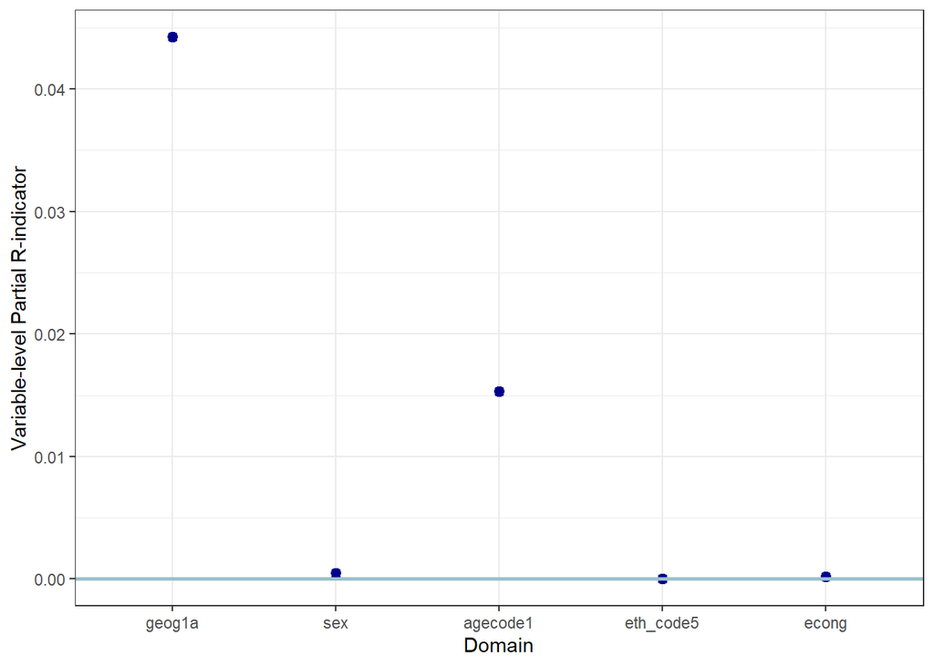

```r
      plot(p1)
```

R-indicator by the category-level.

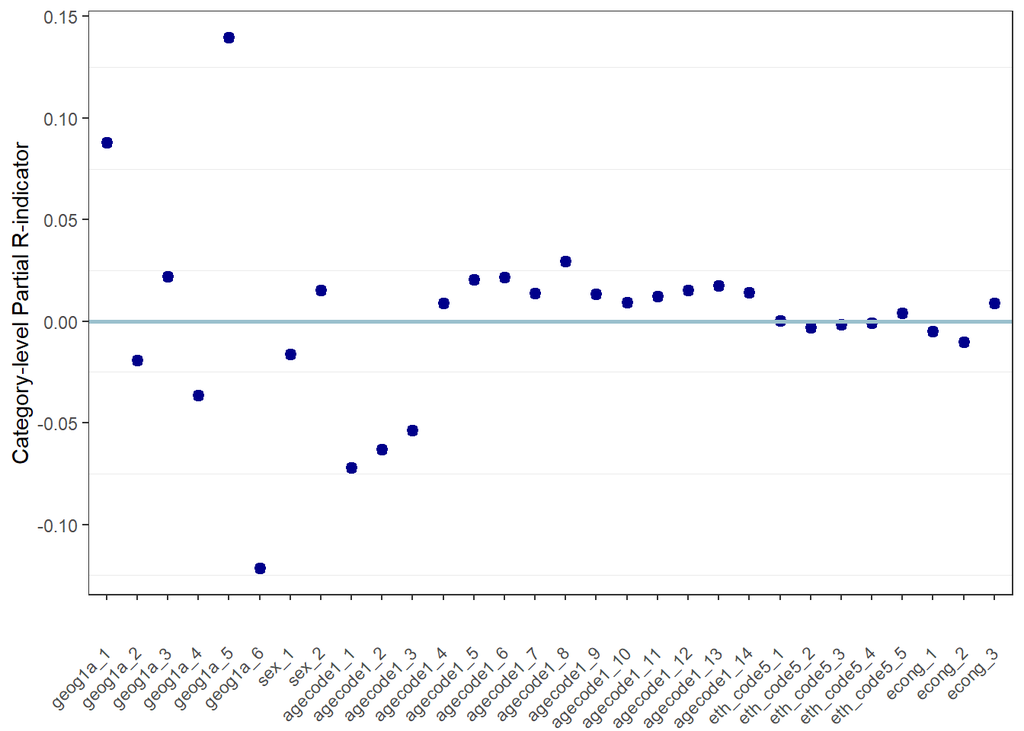

```r
       plot(p2)
```

This concludes the manual. Thank you for your attention. Please get in touch with any query or errata at email.

[^1]: As the `var` object is treated as global macro, the programme runs automatically using the information stored in global macro, and produces the results.
[^2]: We also provide `fn_maxvar4_freq_table()` for users who declare four categorical variables
[^3]: We also provide `fn_maxvar4_freq_table()` for users who declare four categorical variables
[^4]: This is essentially almost identical to `table(display_domain$fct_domain)`, but the approach `tabyl` produces percent by default
[^5]: This is to avoid warnings messages from R when R searches for a particular function from two different packages.